# Présentation des données

Antoine Buvat / Julien Langevin / Mickaël Walter

20/09/2019

## Données brutes

Dans le cadre de notre démonstrateur, nous avons fait le choix d’utiliser une base de données issue d’un site open source. Le base de données se nomme **Credit Card Fraud Detection**. Elle est disponible sur ce site https://www.kaggle.com/mlg-ulb/creditcardfraud.

Cette base de données contient la liste de toute les transactions faite par carte de crédit en Septembre 2013 par des clients européens possédant une carte de crédit. De plus, elle fait la distinction entre les transactions frauduleuses et les transactions légales.

Notre jeu de données contient **284807 observations** ainsi que les **31 variables** suivantes:

- **Amount**: Coût de la transaction
- **V1 à V28**: variables qui ont été obtenues à l’aide d’une ACP et qui ont été anonymisées pour des raisons de confidentialité.
- **Time**: seconde entre la premiere transaction et la transaction en question.
- **Class**: prend pour modalité 1 si la transaction est frauduleuse et 0 sinon. Il s’agit de notre variable de réponse.

On cherche à construire un modèle qui prédit la fraude ou non d’un client en fonction des autres variables par la méthode de **machine à vecteur de support** (SVM).

## Problèmes de déséquilibre

Sur les 284807 observations, nous pouvons seulement observer **492 cas de fraude**, soit **0.172%**. En effet, la fraude correspond à un évenement rare et c’est pour cela que notre base de données est donc fortement déséquilibrée.

Cependant, il existe deux types de méthodes pour répondre a cette problèmatique:

- La **méthode Random Under Sampling** (RUS): cette méthode consiste à retirer une partie des observations non frauduleuses de l’échantillion d’apprentissage de manière aléatoire, afin qu’elle ne représente plus qu’une certaine proportion fixé de l’échantillon. Elle a pour avantage de limiter le temps d’exécution de l’algorithme puisqu’elle utilise beaucoup moins de ressources. En effet, notre base de données est beaucoup plus petite par rapport à la base de données originale. En revanche, on perd de l’information. Pour éviter ce problème, il existe des méthodes d’undersampling telle que la One-Sided Selection (OSS) qui consiste à éliminer certains individus de la classe majoritaire par la méthode des voisins les plus proches.
- La **méthode Random Over Sampling** (ROS): cette méthode consiste à augmenter le nombre d’individus frauduleux par une duplication aléatoire, afin qu’ils représentent une certaine proportion fixé de l’échantillon d’apprentissage.Dans cette méthode, on ne perd aucune information et donc les résultats seront meilleurs. En revanche, on a un risque d’overfitting liée à la présence de multiple individus identiques.Pour éviter ce risque, on peut recourir à la méthode du **SMOTE** (Synthetic Minority Over-sampling Technique), méthode d’oversampling qui consiste à créer des individus frauduleux à partir des individus déja existant.

La méthode d’oversampling par SMOTE est jugé de manière général comme la plus performante.

## Nos modifications

Mais viens notre second problème, technique cette fois: notre jeu de données requiert énormément de ressources. Notre objectif étant de construire un démonstrateur simple et ludique de la méthode de **machine à vecteur de support** (SVM), nous avons fait le choix de modifier nos données par undersampling en utilisant **la méthode du Random Under Sampling** (RUS). Ci-dessous vous observerez la façon dont nous avons procéder:

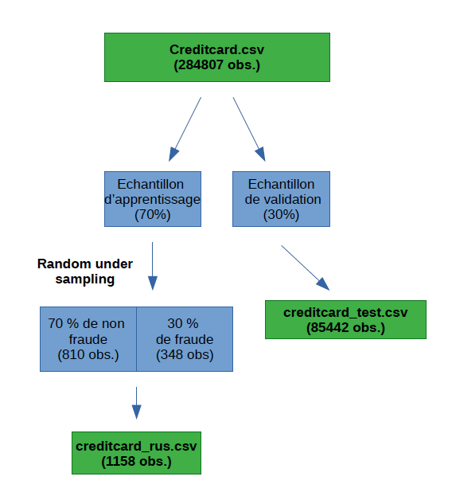

Nous avons décider de travailler avec un **ratio 70/30** pour nos échantillon d’apprentissage et de validation. Ensuite, lors de la modification de l’échantillon d’apprentissage via Random Under Sampling, nous avons fait le choix d’avoir aussi un **ratio 70/30** entre les transactions frauduleuses et non frauduleuses.

Finalement, on travaillera sur un échantillon d’apprentissage avec **348 transactions frauduleuses** et **810 transactions non frauduleuses**, soit un total de **1158 observations**. De plus, notre échantillon de validation possédera 85442 transactions avec 144 transactions frauduleuses, soit 0,17% de l’échantillon.

Avant de procéder à l’estimation du SVM, nous voulons savoir quelles sont les variables les plus importantes qui expliquent notre variable de réponse Class. Avec cet objectif en tête, nous avons décider de faire une **matrice de corrélation** sur notre base de données d’apprentissage Random Under Sampling. De plus, nous testons la **significativité des p-values** à un **seuil de 5%**. Toutes les corrélations ayant une **p-value supérieur à 5%** seront considérées comme **non significatives**. On va donc les exclure de notre analyse.

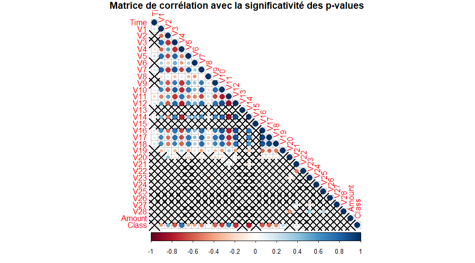

Sur le graphique, nous allons nous focaliser sur la dernières lignes. On peut observer les corrélations entre notre variable de réponse Class et les variables explicatives. Toutes les corrélations qui ne sont pas significatives sont **barrées par une croix**.

Au final, nous conservons les variables explicatives suivantes: **V1, V2, V3, V4, V5, V6, V7, V8, V9, V10, V11, V12, V14, V16, V17, V18, V19, V21**.